# PassGen

[figure not shown]

A tool used to generate and menage passwords. It allows to generate up to 10 passwords, encrypt them and saved to a password-protected *.pgen file. Using the same program *.pgen file can be opened and decrypted using password provided during encryption step.

## Motivation

The aim of this project was to help menage passwords and keep them in the ecrypted form for safety reasons. It is especially important for users that have to change passwords on a regular basis.

## Installation

Standalone executables are available and tested for Windows 10 and Linux(Ubuntu 18.04) systems. Please download the program using [Windows](https://github.com/piotrpatrzylas/PassGen/blob/master/Windows/PassGen.exe) or [Linux](https://github.com/piotrpatrzylas/PassGen/blob/master/Linux/PassGen) version. A copy of [GPL licence](https://github.com/piotrpatrzylas/PassGen/blob/master/Linux/gpl-3.0.txt) is also available.

## Usage

Open the file

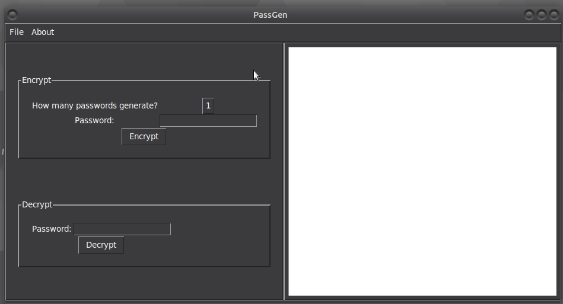

Choose how many passwords to generate and what will be master password (to encrypt/decrypt a file)

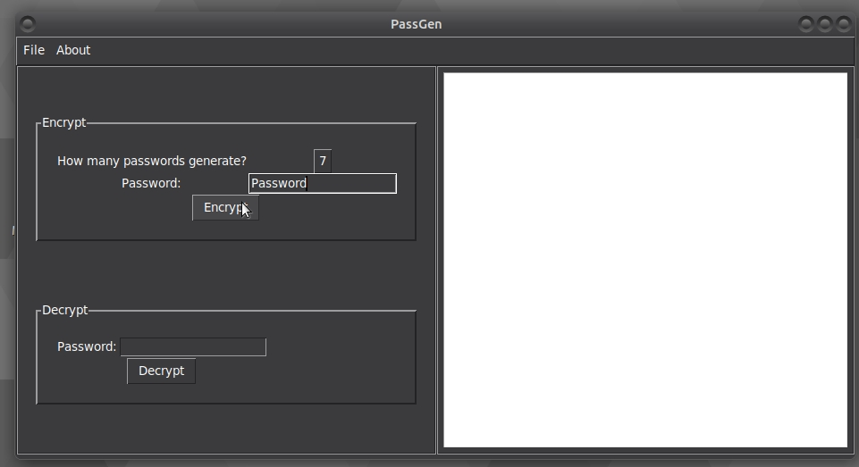

Click encrypt to preview the passwords

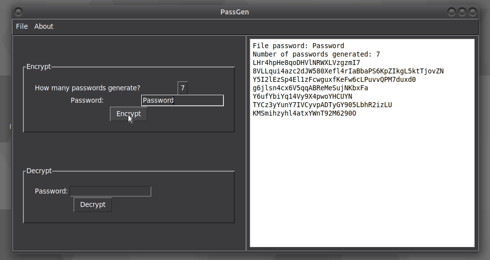

Click on File->Save to save encrypted file with the passwords (in *.pgen format)

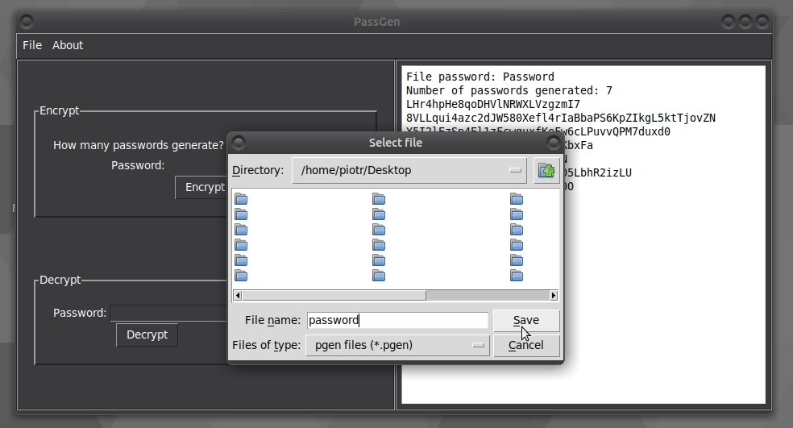

Above file can be opened with this program by clicking on File->Open

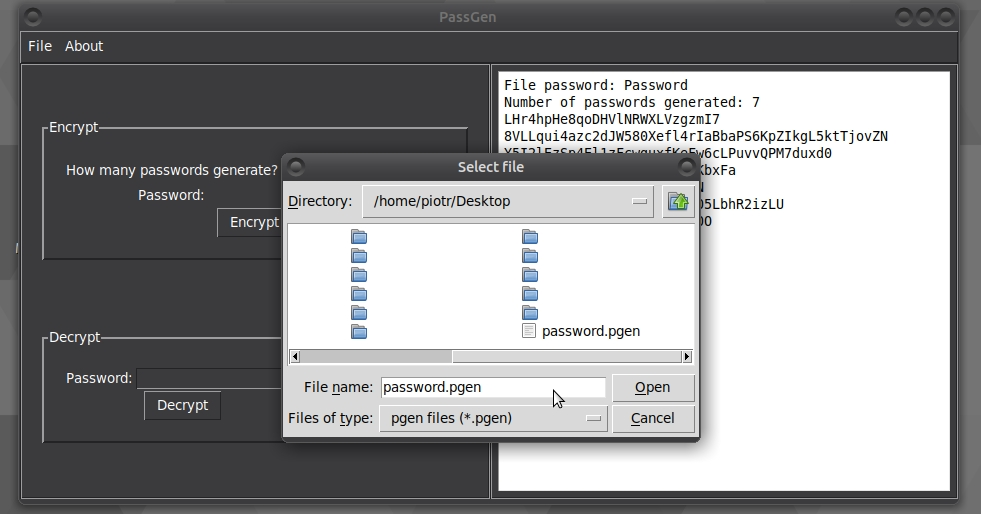

Encrypted file will be displayed (same text is stored in the file)

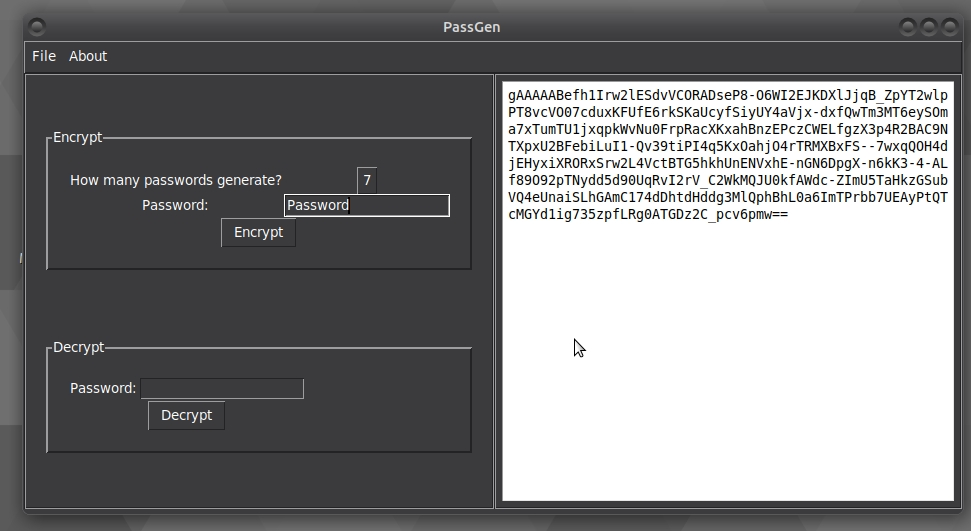

To decrypt input the file password and click Decrypt

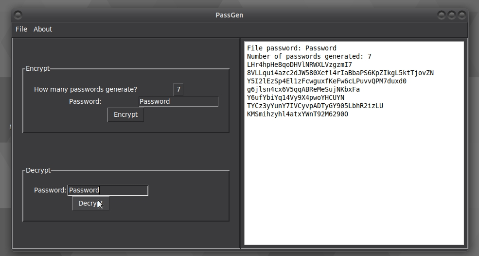

## Licence

GNU GENERAL PUBLIC LICENSE Version 3

## Author

Piotr Patrzylas, London 2020